# Analysis for Project

# Introduction

Back to top

Use this R Markdown to perform the main analysis for the project. I use this basically as a lab notebook. It contains the main analysis and a variety of sensitivity analysis. The code in this documents serves as a baseline for the eventual tables and figures that will go into the paper. At the same time it will serve as a record of all supplementary analyses performed.

# Charts

```
## ethnicity
## race
## sex.act
## fetish
## voyeur.super
## gay
## breasts
```

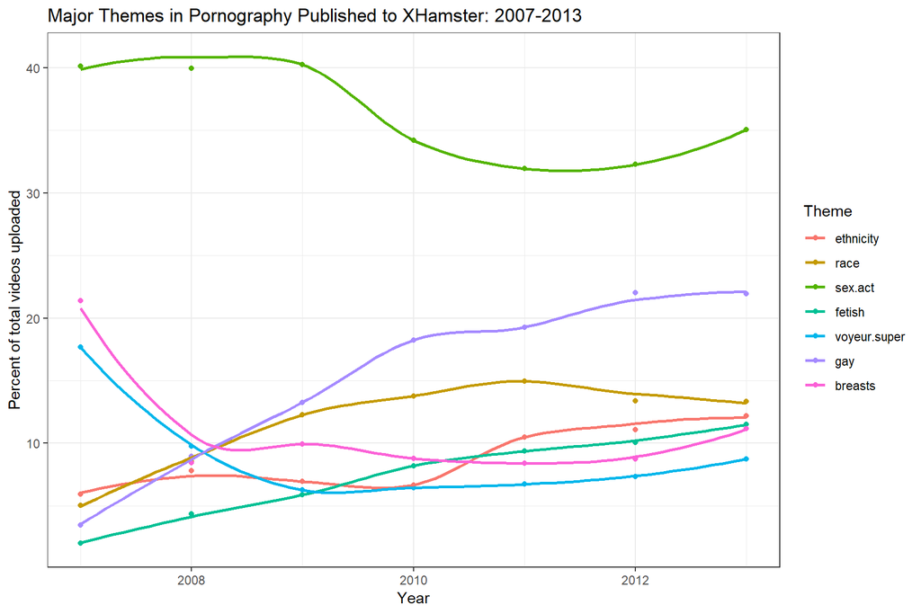

This is ultimately the chart I used to examine how prevalent certain tag families were. I initially ran it with all of the tag families, but it was information overload. I wound up splitting it across several charts for readability; 12+ lines was just an incomprehensible jumble. In the script I commented out specific tag families to find combinations that showed certain trends on the same graph, so I could more easily explain what trends I found most relevant to each other.

# Tag Family Tables

table(porn$breasts) table(porn$voyeur.super) table(porn$ethnicity)

```
##
##      1      2
## 715704  70418
```

```
##
##      1      2
## 729488  56634
```

```
##
##      1      2
## 708173  77949
```

Initially done to test whether each tag family was incorporating all tags correctly, I found these simple test tables actually showed that the tag family variables I had created could lend some explanatory power. Each of the tag families wound up encapsulating around 70,000 observations, which is around 9% of the total dataset. I made 11, which meant they came pretty close to filling the entire population, despite several categories being left out.

# Latent Class Analysis

## Code

porn.subsample <- porn[sample(1:nrow(porn), 5000),]

# Early Graphs

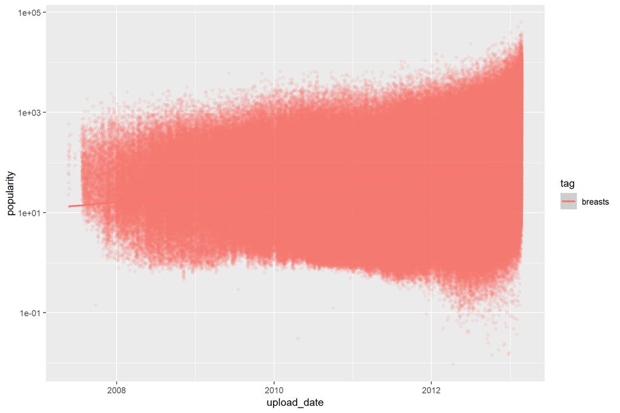

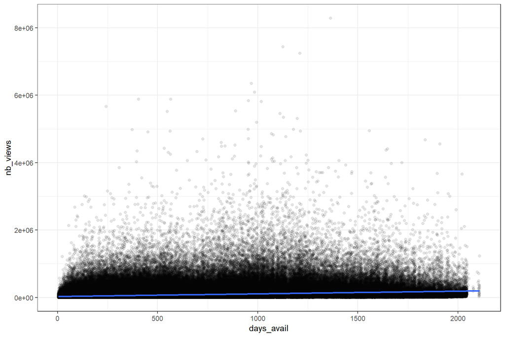

These graphs were some of my initial explorations into what the data looked like. I was trying to get a sense of what the distribution over time was for videos, as well as how time available on the site affected the number of views. These provided too much noise however, so were excluded from the final analysis.